# El Cañon del Sumidero

Black bird

08/08/2013

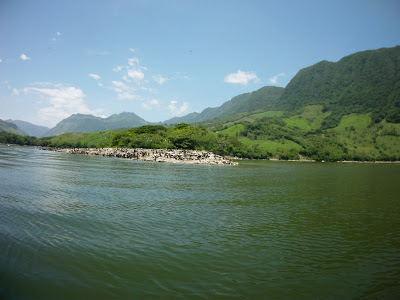

A unos 30 kilómetros de San Cristobal de las Casas se encuentra un poblado llamado Chiapa de Corzo, es de esos pueblos que si no te dicen podrías pasar cientos de veces enfrente y no te percartas que existe, sin embargo, Chiapa es nada más que un “Pueblo Mágico” decretado “Patrimonio Cultural (inmaterial) de la humanidad” por una danza regional que, infelizmente, no nos tocó, así que poco puedo decir de ella. En realidad, poco les puedo decir de Chiapa porque no la visitamos ya que sólo fuimos a su embarcadero pues es desde aquí que salen las lanchas que dan el paseo por el Grijalva, en las fauces del Cañón del Sumidero.

## Pero entonces, hablemos del Cañón del sumidero; tips generales.

1. llegando por la carretera hay unos puestos de comida tradicional que se ven fabulosos, nosotros no comimos ahí pero seguro que te das un festín.
2. En la plaza principal encontrarás locales que te llevan al embarcadero, vale la pena dejarse llevar pues no cobran extra y yo creo que les dan una comisión, además, no hay letreros para llegar.
3. Ve en la mañana (creo que la primera excursión sale a las 8am) o en la tarde, porque nosotros fuimos a las 12 y nooo m***
4. Puedes subir cualquier líquido a la lancha (cualquiera) pero no abuses, la chela… digo, refresco, se te va calentar muy rápido, suerte para nosotros la cooperativa instaló una “lancha bar” que te alcanza durante tu recorrido y te vende bebidas y botanas.
5. Las lanchas NO SON TECHADAS por lo que se recomienda llevar bloqueador, sombrero, etc.

## Entonces, el recorrido.

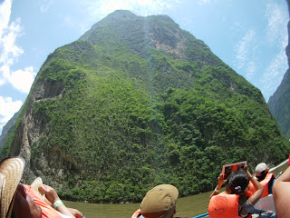

El recorrido en lancha que sale de Chiapa de Corso por el cañón del sumidero es manejado por una cooperativa de 5 representantes, todos locales, por lo que (después de pasar a San Cristobal) estábamos muy contentos de pagar nuestros 130 pesotes para el paseo (además parte del dinero va a la CONANP lo cual uno siempre agradece). El recorrido dura aproximadamente 2 horas río arriba (¿o será abajo?)durante el trayecto vimos cocodrilos tomando el sol, monos araña en el cotorreo y algunos pájaros (de hecho si eres fan de las aves, te recomiendo ir muy temprano, seguramente habrá muchos). Ahora no solo la vida animal asombra, en realidad es la más tranquila, es la vegetación y la geología la que hacen todo el show, elevaciones de hasta 1000 metros (Lanchero, 2013) cubiertas de una vegetación verde verde tupidas de plantas y cascadas de agua cristalina se apoderan del paisaje de todo el recorrido. Incluso, en algún momento del mismo, si tienen suerte, serán bañados por las frías y refrescantes aguas de la cascada del Árbol de Navidad“. El recorrido termina en la presa de Chicoasén, en medio del Parque Reserva Natural Cañón del Sumidero. Durante la ida, el lanchero va parando en lugares específicos para que todos digamos en coro”ooooooh" “aaaaaaaaah” “WoooooooW”, en el regreso, directo al embarcadero te da tiempo de pensar y pensar, a mi, me dieron unas ganas enormes de subir a lo más alto de las montañas y brincar, he decidido que voy a brincar de paracaídas.

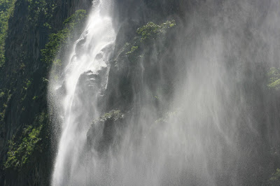

El plan B. Algo que ya no logramos hacer y que se me antojó es la visitar por arriba del Cañón. Hay dos maneras de visitar el parquel, la primera como les comenté, por abajo y la segunda es tomar el auto y seguir por una carreterita (si no me equivoco sale de Tuxtla) y ves todo desde arriba, durante el sendero hay 5 puntos de observación, siendo que el más escondido tiene un restaurante mirador que ha de estar increíble. Pena, será para la próxima.

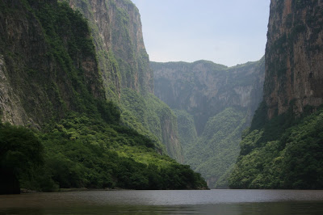